# Temporal_Genomics_Workshop_TemporalGenomics

Contents

- 1 Workshop Overview:
- 2 Load Required Libraries
- 3 Load temporal genomic data (dadi data dictionaries)
- 4 Build 2D Site Frequency Spectra (2dSFS) for Has02 → Has23
- 5 Visualize the 2dSFS (all effect classes)
- 6 Compare Allele Frequency Categories (Rare vs Moderate bins from a sdSFS)
- 7 Statistical Metrics per Row of the 2dSFS
- 8 Bootstrapped Confidence Intervals
- 9 Fit a simple neutral model (split with symmetric migration) to the low-effect 2dSFS
- Subsampling Low-Effect Mutations for Comparison
- 11 Discussion, interpretation & exercises

# Temporal Genomics — Hands-on Workshop (Python / Jupyter)

## 1 Workshop Overview:

In this workshop, you will learn to analyse **temporal genomic data** — data from the same population sampled at two different time points.

**Explore allele frequency changes over time (one population: Has02 → Has23)**

**What you'll learn**

- Load temporal genomic data for mutations of different functional effects
- Build and visualize **2D Site Frequency Spectra (2dSFS)** with `dadi` across mutation effect classes
- Quantify **frequency shifts** between timepoints
- Compare mutation categories (high-, low-, moderate-, and synonymous-effect)
- Compute per-row conditional distributions (p(j \mid i))
- Perform **bootstrap-based confidence intervals**, **statistical tests** (χ², Jensen–Shannon divergence). and **permutation tests**
- Fit a simple **neutral demographic model** and inspect residuals
- Interpret results and link them to evolutionary processes

> This notebook is *ready-to-run* in a conda environment with `dadi`, `numpy`, `matplotlib`, `pandas`, `scipy`, and `seaborn` installed.

## 2 Load Required Libraries

Load essential Python packages for numerical analysis, statistics, and plotting.

**Show codeHide codeCopyable source**

```python
import numpy as np
import pandas as pd
import matplotlib.pyplot as plt
import seaborn as sns
from scipy.stats import chisquare # Chi-square test
from scipy.spatial.distance import jensenshannon # JSD divergence
from matplotlib.colors import TwoSlopeNorm, SymLogNorm
from matplotlib.ticker import MaxNLocator
import dadi
```

## 3 Load temporal genomic data (dadi data dictionaries)

- We’ll use **pre-annotated SNPs** separated by **functional effect** (from snpEff).
- Replace the file paths below with your own `dadi`-formatted `.vcf.data` files exported from your pipeline (these are simple text-based dictionaries expected by `dadi.Misc.make_data_dict`).

We treat two timepoints for the same population: **Has02** (older) and **Has23** (newer).  
Mutation effect classes (example file naming convention used here):

- `snpEff_Ann_HighEff_...`
- `snpEff_Ann_LowEff_...`
- `snpEff_Ann_ModEff_...`
- `snpEff_Ann_SynVar_...`

**Show codeHide codeCopyable source**

```python
# === Replace these paths with your files ===
snp_syn = 'snpEff_Ann_SynVar_merged_with_header_ChromModified.vcf.data'
snp_high = 'snpEff_Ann_HighEff_merged_with_header_ChromModified.vcf.data'
snp_low = 'snpEff_Ann_LowEff_merged_with_header_ChromModified.vcf.data'
snp_mod = 'snpEff_Ann_ModEff_merged_with_header_ChromModified.vcf.data'

# Create dadi data dictionaries (these parse the simple 'vcf.data' files)
dd_syn = dadi.Misc.make_data_dict(snp_syn)
dd_high = dadi.Misc.make_data_dict(snp_high)
dd_low = dadi.Misc.make_data_dict(snp_low)
dd_mod = dadi.Misc.make_data_dict(snp_mod)

print('data dicts created: syn, high, low, mod')
```

```
data dicts created: syn, high, low, mod
```

## 4 Build 2D Site Frequency Spectra (2dSFS) for Has02 → Has23

- We generate polarized (ancestral/derived known) 2dSFS objects using `dadi.Spectrum.from_data_dict`.
- Set `projections` to sensible integer projections for each time point (number of chromosomes retained after down-projection).
- The 2dSFS shows the joint distribution of derived allele frequencies in Has02 vs Has23.

**Show codeHide codeCopyable source**

```python
# === Build spectra (adjust projections to your dataset) ===
proj = [24, 40]   # example projections: replace if needed

Has_syn = dadi.Spectrum.from_data_dict(dd_syn, pop_ids=['Has02','Has23'], projections=proj, polarized=True)
Has_high = dadi.Spectrum.from_data_dict(dd_high, pop_ids=['Has02','Has23'], projections=proj, polarized=True)
Has_low = dadi.Spectrum.from_data_dict(dd_low, pop_ids=['Has02','Has23'], projections=proj, polarized=True)
Has_mod = dadi.Spectrum.from_data_dict(dd_mod, pop_ids=['Has02','Has23'], projections=proj, polarized=True)

print('Spectra shapes (rows = i in Has02, cols = j in Has23):')
print('Has_high', Has_high.data.shape, 'total sites =', Has_high.data.sum())
print('Has_low ', Has_low.data.shape,  'total sites =', Has_low.data.sum())
print('Has_mod ', Has_mod.data.shape,  'total sites =', Has_mod.data.sum())
print('Has_syn ', Has_syn.data.shape,  'total sites =', Has_syn.data.sum())
```

```
Spectra shapes (rows = i in Has02, cols = j in Has23):
Has_high (25, 41) total sites = 25972.0
Has_low  (25, 41) total sites = 216518.0
Has_mod  (25, 41) total sites = 243912.0
Has_syn  (25, 41) total sites = 185316.0
```

## 5 Visualize the 2dSFS (all effect classes)

- We use `dadi.Plotting.plot_single_2d_sfs`. The `vmin`/`vmax` are chosen robustly to avoid invalid colorbar errors.
- Each pixel represents the number of SNPs with a given derived allele count (i, j) in Has02 and Has23.

**Show codeHide codeCopyable source**

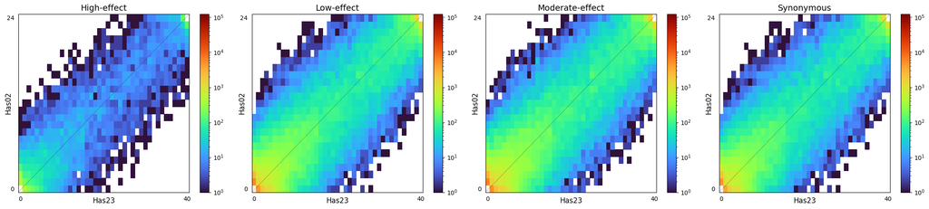

```python
# === Visualize four 2dSFS side-by-side ===
all_specs = [Has_high, Has_low, Has_mod, Has_syn]
nonempty = [d for d in all_specs if getattr(d,'data',None) is not None and d.data.size>0]

if len(nonempty)==0:
    print('No spectra with data found.')
else:
    vmin = max(1, min([d.data.min() for d in nonempty]))
    vmax = max([d.data.max() for d in nonempty])

    fig, axes = plt.subplots(1, 4, figsize=(22,5))
    cmap = 'turbo'
    dadi.Plotting.plot_single_2d_sfs(Has_high, vmin=vmin, vmax=vmax, cmap=cmap, pop_ids=('Has02','Has23'), ax=axes[0])
    dadi.Plotting.plot_single_2d_sfs(Has_low,  vmin=vmin, vmax=vmax, cmap=cmap, pop_ids=('Has02','Has23'), ax=axes[1])
    dadi.Plotting.plot_single_2d_sfs(Has_mod,  vmin=vmin, vmax=vmax, cmap=cmap, pop_ids=('Has02','Has23'), ax=axes[2])
    dadi.Plotting.plot_single_2d_sfs(Has_syn,  vmin=vmin, vmax=vmax, cmap=cmap, pop_ids=('Has02','Has23'), ax=axes[3])

    titles = ['High-effect', 'Low-effect', 'Moderate-effect', 'Synonymous']
    for ax, t in zip(axes, titles):
        ax.set_title(t, fontsize=14)
        ax.xaxis.label.set_size(12)
        ax.yaxis.label.set_size(12)
        ax.tick_params(axis='both', which='major', labelsize=10)

    plt.tight_layout()
    plt.show()
```

## 6 Compare Allele Frequency Categories (Rare vs Moderate bins from a sdSFS)

- We can compare bins of rare vs moderate frequency alleles to detect potential selection effects.
- We'll define a helper to extract counts in rare and moderate bins (you can adjust thresholds).

**Show codeHide codeCopyable source**

```python
def extract_allele_bins(sfs, rare_max=2, moderate_min=3, moderate_max=8):
    arr = sfs.data
    rare = []
    moderate = []
    n1, n2 = arr.shape
    for i in range(n1):
        for j in range(n2):
            if i==0 and j==0:
                continue
            count = arr[i,j]
            if (i<=rare_max or j<=rare_max) and (i>0 or j>0):
                rare.append(count)
            elif (moderate_min <= i <= moderate_max) and (moderate_min <= j <= moderate_max):
                moderate.append(count)
    return np.array(rare), np.array(moderate)

rare_syn, mod_syn = extract_allele_bins(Has_syn)
rare_high, mod_high = extract_allele_bins(Has_high)
rare_low, mod_low   = extract_allele_bins(Has_low)
rare_mod, mod_mod   = extract_allele_bins(Has_mod)

print('Example counts lengths: rare_high=', len(rare_high), 'mod_high=', len(mod_high))
```

```
Example counts lengths: rare_high= 188 mod_high= 36
```

### 6.1. Boxplots of rare/moderate bin distributions

**Show codeHide codeCopyable source**

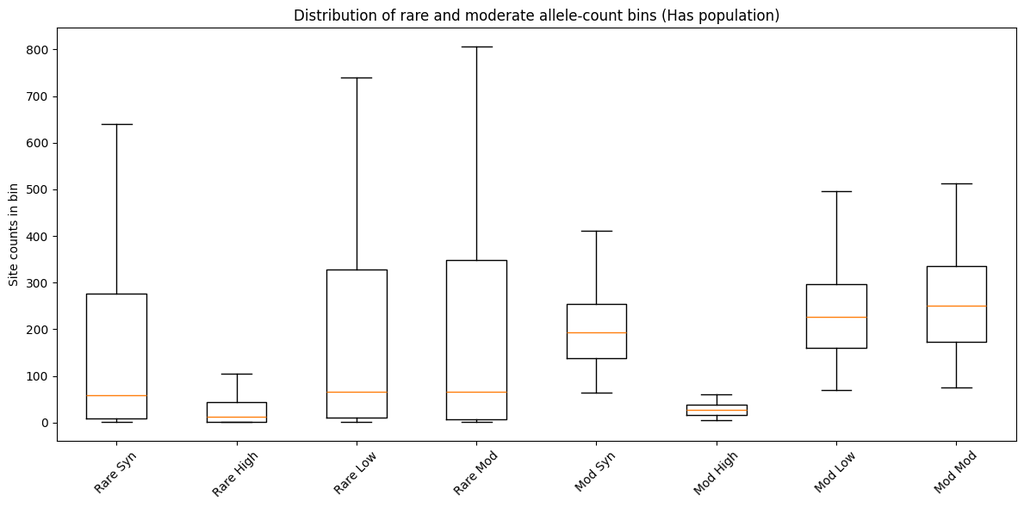

```python
data = [rare_syn, rare_high, rare_low, rare_mod, mod_syn, mod_high, mod_low, mod_mod]
labels = ['Rare Syn','Rare High','Rare Low','Rare Mod','Mod Syn','Mod High','Mod Low','Mod Mod']

plt.figure(figsize=(12,6))
# avoid empty groups
data_nonempty = [d[d>0] if d.size>0 else np.array([0]) for d in data]
plt.boxplot(data_nonempty, labels=labels, showfliers=False)
plt.ylabel('Site counts in bin')
plt.title('Distribution of rare and moderate allele-count bins (Has population)')
plt.xticks(rotation=45)
plt.tight_layout()
plt.show()
```

### 6.2. Density overlays (rare bins): High vs Low effect

We can visualise the shape of these distributions using Kernel Density Estimates (KDE).

**Show codeHide codeCopyable source**

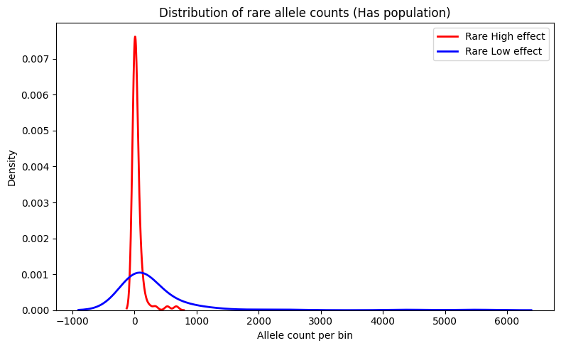

```python
import seaborn as sns
plt.figure(figsize=(8,5))
if np.any(rare_high>0):
    sns.kdeplot(rare_high[rare_high>0], label='Rare High effect', color='red', lw=2)
if np.any(rare_low>0):
    sns.kdeplot(rare_low[rare_low>0], label='Rare Low effect', color='blue', lw=2)
plt.xlabel('Allele count per bin')
plt.ylabel('Density')
plt.title('Distribution of rare allele counts (Has population)')
plt.legend()
plt.tight_layout()
plt.show()
```

## 7 Statistical Metrics per Row of the 2dSFS

- We now compare rows (fixed Has02 frequency, varying Has23) between mutation classes - per-row normalized conditional distributions (p(j \mid i))

We compute row-wise normalized probabilities and show panel plots for rows with sufficient data. This helps visualize how distribution of derived allele counts in Has23 shifts relative to Has02 for each starting i.

We calculate:

- χ² statistic comparing histograms
- Jensen–Shannon divergence (JSD)
- Mean shifts and fraction of mass left of the diagonal

### 7.1. Helper functions for statistics and normalisation:

**Show codeHide codeCopyable source**

```python
# -------------------------
# 2. Helper functions
# -------------------------

def chisq_on_hist(c1, c2, min_per_bin=5):
    c1 = np.asarray(c1, float)
    c2 = np.asarray(c2, float)
    mask = (c1 + c2) >= min_per_bin
    if mask.sum() < 2:
        return np.nan, np.nan
    c1m, c2m = c1[mask], c2[mask]
    total = (c1m.sum() + c2m.sum()) / 2.0
    if c1m.sum() == 0 or c2m.sum() == 0:
        return np.nan, np.nan
    c1s = c1m * (total / c1m.sum())
    c2s = c2m * (total / c2m.sum())
    stat, p = chisquare(f_obs=c1s, f_exp=c2s)
    return stat, p

def normalize_row(c):
    c = np.asarray(c, float)
    s = c.sum()
    return c / s if s > 0 else np.zeros_like(c)

def row_metrics(sfs_high, sfs_low, row_index):
    cH = sfs_high.data[row_index, :].astype(float)
    cL = sfs_low.data[row_index, :].astype(float)
    pH = normalize_row(cH)
    pL = normalize_row(cL)
    chi2, p_chi = chisq_on_hist(cH, cL)
    try:
        jsd = jensenshannon(pH, pL, base=2.0)
    except Exception:
        jsd = np.nan
    j = np.arange(cH.size)
    deltaH = ((j - row_index) * cH).sum() / cH.sum() if cH.sum() > 0 else np.nan
    deltaL = ((j - row_index) * cL).sum() / cL.sum() if cL.sum() > 0 else np.nan
    fracLeftH = cH[j < row_index].sum() / cH.sum() if cH.sum() > 0 else np.nan
    fracLeftL = cL[j < row_index].sum() / cL.sum() if cL.sum() > 0 else np.nan
    mean_j_high = (j * pH).sum() if pH.sum() > 0 else np.nan
    mean_j_low  = (j * pL).sum() if pL.sum() > 0 else np.nan
    return dict(row=row_index,
                n_high=int(cH.sum()), n_low=int(cL.sum()),
                chi2=chi2, p_chi=p_chi, jsd=jsd,
                delta_mean_high=deltaH, delta_mean_low=deltaL,
                frac_left_high=fracLeftH, frac_left_low=fracLeftL,
                mean_j_high=mean_j_high, mean_j_low=mean_j_low)

def bootstrap_row_diffs(cH, cL, row_index, B=1000, rng=None):
    if rng is None:
        rng = np.random.default_rng(42)

    def _safe_mean_j(counts):
        counts = np.asarray(counts, float)
        tot = counts.sum()
        if tot <= 0:
            return np.nan
        j = np.arange(counts.size)
        return (j * (counts / tot)).sum()

    def _safe_E_delta(counts, row_index):
        counts = np.asarray(counts, float)
        tot = counts.sum()
        if tot <= 0:
            return np.nan
        j = np.arange(counts.size)
        delta = j - row_index
        return (delta * counts).sum() / tot

    def _safe_frac_left(counts, row_index):
        counts = np.asarray(counts, float)
        tot = counts.sum()
        if tot <= 0:
            return np.nan
        j = np.arange(counts.size)
        return counts[j < row_index].sum() / tot

    d_meanj = _safe_mean_j(cL) - _safe_mean_j(cH)
    d_Ed    = _safe_E_delta(cL, row_index) - _safe_E_delta(cH, row_index)
    d_fl    = _safe_frac_left(cL, row_index) - _safe_frac_left(cH, row_index)

    bmj, bEd, bfl = [], [], []
    for _ in range(B):
        bH = rng.poisson(np.maximum(cH, 0))
        bL = rng.poisson(np.maximum(cL, 0))
        bmj.append(_safe_mean_j(bL) - _safe_mean_j(bH))
        bEd.append(_safe_E_delta(bL, row_index) - _safe_E_delta(bH, row_index))
        bfl.append(_safe_frac_left(bL, row_index) - _safe_frac_left(bH, row_index))

    def ci(arr):
        return np.nanpercentile(arr, 2.5), np.nanpercentile(arr, 97.5)

    lo_mj, hi_mj = ci(bmj)
    lo_Ed, hi_Ed = ci(bEd)
    lo_fl, hi_fl = ci(bfl)

    return dict(row=row_index,
                d_meanj=d_meanj, lo_meanj=lo_mj, hi_meanj=hi_mj,
                d_Ed=d_Ed,       lo_Ed=lo_Ed,   hi_Ed=hi_Ed,
                d_fl=d_fl,       lo_fl=lo_fl,   hi_fl=hi_fl)

# =========================
# Per-row normalized p(j|i) panel plots
# =========================
def analyze_sfs_rows(
    sfs_high, sfs_low,
    pop_label="Pop",
    start_row=1, end_row=None,
    ncols=4,
    ymax_prob=0.12,
    mean_lines=True,
    pop1_name=None, pop2_name=None,
    min_row_sites=10,
    adaptive_ylim=True,
    show_equal_freq=True,
    main_title=None,
    subtitle=None,
    top_pad=0.88,
    title_y=0.93,
    subtitle_y=0.90,
    title_kwargs=None,
    subtitle_kwargs=None,
    subplot_title_fontsize=10
):
    n_y, n_x = sfs_high.data.shape
    assert sfs_low.data.shape == (n_y, n_x), "SFS shapes must match"
    n1 = n_y - 1
    n2 = n_x - 1

    if pop1_name is None:
        pop1_name = f"{pop_label}02"
    if pop2_name is None:
        pop2_name = f"{pop_label}23"
    if end_row is None:
        end_row = n_y - 1
    rows = np.arange(start_row, end_row + 1, dtype=int)

    tot_high = sfs_high.data.sum(axis=1)
    tot_low = sfs_low.data.sum(axis=1)
    metrics = [row_metrics(sfs_high, sfs_low, i) for i in rows]
    df = pd.DataFrame(metrics).sort_values("row")

    n_panels = len(rows)
    nrows = int(np.ceil(n_panels / ncols))
    fig, axes = plt.subplots(nrows=nrows, ncols=ncols, figsize=(4 * ncols, 2.8 * nrows),
                             sharex=True, sharey=False, constrained_layout=False)
    axes = np.atleast_1d(axes).ravel()
    legend_shown = False

    for ax, i in zip(axes, rows):
        cH = sfs_high.data[i, :].astype(float)
        cL = sfs_low.data[i, :].astype(float)
        nH = int(tot_high[i])
        nL = int(tot_low[i])

        if (nH + nL) < min_row_sites or (cH.sum() == 0 and cL.sum() == 0):
            ax.text(0.5, 0.5, f"Row {i}\nno/too few sites\n(high={nH}, low={nL})",
                    ha='center', va='center', transform=ax.transAxes)
            ax.set_axis_off()
            continue  # Skip setting title and labels for this axis

        pH = normalize_row(cH)
        pL = normalize_row(cL)
        x = np.arange(n_x)
        ax.plot(x, pH, 'r-', lw=1.8, alpha=0.95, label='High (norm)' if not legend_shown else None)
        ax.plot(x, pL, 'b--', lw=1.8, alpha=0.95, label='Low (norm)' if not legend_shown else None)

        if show_equal_freq and n1 > 0:
            j_eq = (n2 / n1) * i
            ax.axvline(j_eq, color='k', ls=':', lw=1.2, alpha=0.8,
                       label='Equal frequency (p02=p23)' if not legend_shown else None)

        if mean_lines:
            mjh = df.loc[df.row == i, 'mean_j_high'].values[0]
            mjl = df.loc[df.row == i, 'mean_j_low'].values[0]
            if np.isfinite(mjh):
                ax.axvline(mjh, color='red', ls='--', lw=1.2, alpha=0.95,
                           label='High mean j' if not legend_shown else None)
            if np.isfinite(mjl):
                ax.axvline(mjl, color='blue', ls='--', lw=1.2, alpha=0.95,
                           label='Low mean j' if not legend_shown else None)

        if adaptive_ylim:
            y_max = max(pH.max(), pL.max())
            ax.set_ylim(0, max(y_max * 1.15, 0.02))
        else:
            ax.set_ylim(0, ymax_prob)

        mrow = df[df.row == i].iloc[0]
        ax.set_title(f"Row {i} | sites: high={nH}, low={nL}\nJSD={mrow.jsd:.3f} | χ² p={mrow.p_chi:.2g}",
                     fontsize=subplot_title_fontsize)
        ax.set_xlabel(f"{pop2_name} derived allele count (j)")
        ax.set_ylabel(f"p(j | {pop1_name} = {i})")

        if not legend_shown:
            ax.legend(loc="upper right", fontsize=8, frameon=False)
            legend_shown = True

    for k in range(len(rows), len(axes)):
        fig.delaxes(axes[k])

    fig.tight_layout(rect=[0, 0, 1, top_pad])

    if main_title:
        tkw = dict(fontsize=14, fontweight='bold')
        if title_kwargs:
            tkw.update(title_kwargs)
        fig.text(0.5, title_y, main_title, ha='center', va='top', **tkw)

    if subtitle:
        skw = dict(fontsize=11, color='gray')
        if subtitle_kwargs:
            skw.update(subtitle_kwargs)
        fig.text(0.5, subtitle_y, subtitle, ha='center', va='top', **skw)

    plt.show()
    return df
```

### 7.2. Row-Wise Normalized p(j|i) Plots

These plots show how the allele frequency in Has23 depends on the starting frequency in Has02.

**Show codeHide codeCopyable source**

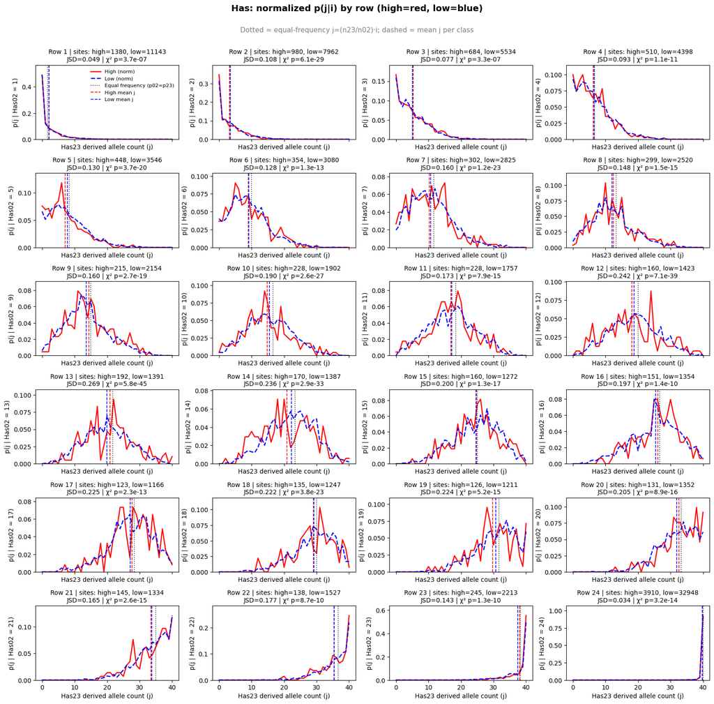

|  | row | n_high | n_low | chi2 | p_chi | jsd | delta_mean_high | delta_mean_low | frac_left_high | frac_left_low | mean_j_high | mean_j_low |
| --- | --- | --- | --- | --- | --- | --- | --- | --- | --- | --- | --- | --- |
| 0 | 1 | 1380 | 11143 | 68.109648 | 3.695666e-07 | 0.049086 | 1.086232 | 1.161088 | 0.489855 | 0.492955 | 2.086232 | 2.161088 |
| 1 | 2 | 980 | 7962 | 191.153944 | 6.062290e-29 | 0.107862 | 1.243878 | 1.430168 | 0.450000 | 0.423888 | 3.243878 | 3.430168 |
| 2 | 3 | 684 | 5534 | 75.323687 | 3.321765e-07 | 0.077494 | 2.238304 | 2.159740 | 0.358187 | 0.346043 | 5.238304 | 5.159740 |
| 3 | 4 | 510 | 4398 | 106.428199 | 1.070263e-11 | 0.093171 | 2.262745 | 2.552751 | 0.364706 | 0.337426 | 6.262745 | 6.552751 |
| 4 | 5 | 448 | 3546 | 156.261520 | 3.714352e-20 | 0.130380 | 2.095982 | 2.798928 | 0.348214 | 0.322053 | 7.095982 | 7.798928 |

```python
# =========================
# Call the per-row panel plots:
# =========================

df_has_rows = analyze_sfs_rows(
    Has_high, Has_low,
    pop_label="Has",
    start_row=1,
    end_row=None,
    ncols=4,
    ymax_prob=0.12,
    mean_lines=True,
    pop1_name="Has02",
    pop2_name="Has23",
    min_row_sites=10,
    adaptive_ylim=True,
    show_equal_freq=True,
    main_title="Has: normalized p(j|i) by row (high=red, low=blue)",
    subtitle="Dotted = equal-frequency j=(n23/n02)·i; dashed = mean j per class",
    top_pad=0.88,
    title_y=0.93,
    subtitle_y=0.90,
    subplot_title_fontsize=10
)

df_has_rows.head()
```

## 8 Bootstrapped Confidence Intervals

**Summary plots with bootstrap confidence intervals:** estimate uncertainty in per-row frequency shifts using Poisson bootstrapping.

- We compute differences between low- and high-effect classes per-row (mean shifts) with bootstrap CI via Poisson resampling.
- This gives a compact summary and uncertainty.

**Show codeHide codeCopyable source**

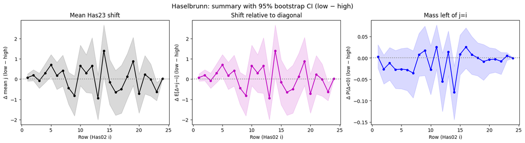

|  | row | d_meanj | lo_meanj | hi_meanj | d_Ed | lo_Ed | hi_Ed | d_fl | lo_fl | hi_fl |
| --- | --- | --- | --- | --- | --- | --- | --- | --- | --- | --- |
| 0 | 1 | 0.074856 | -0.098706 | 0.257185 | 0.074856 | -0.098706 | 0.257185 | 0.003100 | -0.023350 | 0.030916 |
| 1 | 2 | 0.186291 | -0.077791 | 0.462287 | 0.186291 | -0.077791 | 0.462287 | -0.026112 | -0.060767 | 0.006557 |
| 2 | 3 | -0.078564 | -0.450153 | 0.291594 | -0.078564 | -0.450153 | 0.291594 | -0.012144 | -0.051817 | 0.024340 |
| 3 | 4 | 0.290006 | -0.170093 | 0.745835 | 0.290006 | -0.170093 | 0.745835 | -0.027280 | -0.071217 | 0.017402 |
| 4 | 5 | 0.702946 | 0.131769 | 1.210426 | 0.702946 | 0.131769 | 1.210426 | -0.026161 | -0.072121 | 0.022054 |

```python
def summary_plot_with_ci(sfs_high, sfs_low, rows=None, B=1000, seed=123,
                         title="Summary with 95% bootstrap CI",
                         pop1_name="Pop02", pop2_name="Pop23"):
    rng = np.random.default_rng(seed)
    n_y, _ = sfs_high.data.shape
    if rows is None:
        rows = np.arange(1, n_y)
    rows = np.array(sorted(rows))

    recs = []
    for i in rows:
        cH = sfs_high.data[i, :].astype(float)
        cL = sfs_low.data[i, :].astype(float)
        recs.append(bootstrap_row_diffs(cH, cL, i, B=B, rng=rng))
    df = pd.DataFrame(recs)

    fig, axs = plt.subplots(1, 3, figsize=(15, 4), constrained_layout=True)
    axs[0].plot(df.row, df.d_meanj, 'k-o', lw=1.5, ms=4)
    axs[0].fill_between(df.row, df.lo_meanj, df.hi_meanj, color='k', alpha=0.15)
    axs[0].axhline(0, color='gray', ls=':')
    axs[0].set_xlabel(f"Row ({pop1_name} i)")
    axs[0].set_ylabel("Δ mean j (low − high)")
    axs[0].set_title(f"Mean {pop2_name} shift")

    axs[1].plot(df.row, df.d_Ed, 'm-o', lw=1.5, ms=4)
    axs[1].fill_between(df.row, df.lo_Ed, df.hi_Ed, color='m', alpha=0.15)
    axs[1].axhline(0, color='gray', ls=':')
    axs[1].set_xlabel(f"Row ({pop1_name} i)")
    axs[1].set_ylabel("Δ E[Δ=j−i] (low − high)")
    axs[1].set_title("Shift relative to diagonal")

    axs[2].plot(df.row, df.d_fl, 'b-o', lw=1.5, ms=4)
    axs[2].fill_between(df.row, df.lo_fl, df.hi_fl, color='b', alpha=0.15)
    axs[2].axhline(0, color='gray', ls=':')
    axs[2].set_xlabel(f"Row ({pop1_name} i)")
    axs[2].set_ylabel("Δ P(Δ<0) (low − high)")
    axs[2].set_title("Mass left of j=i")

    fig.suptitle(title, fontsize=13)
    plt.show()
    return df

# =========================
# Call the summary plots:
# =========================

df_has_summary = summary_plot_with_ci(
    Has_high, Has_low,
    title="Haselbrunn: summary with 95% bootstrap CI (low − high)",
    pop1_name="Has02",
    pop2_name="Has23"
)

df_has_summary.head()
```

## 9 Fit a simple neutral model (split with symmetric migration) to the low-effect 2dSFS

This step fits a pragmatic 4-parameter model using `dadi.Inference.optimize_log` to the low-effect class (used as a neutral baseline), then computes Anscombe residuals to compare observed vs model expectations.

**Show codeHide codeCopyable source**

```python
#  =========================
# 4. --- Fit neutral demographic model (split with symmetric migration)---
# =========================
def fit_split_mig_sym_on_low(data_low, maxiter=5):
    ns = data_low.sample_sizes
    max_n = int(np.max(ns))
    pts_l = [max_n + 10, max_n + 20, max_n + 30]

    def split_mig_sym(params, ns, pts):
        return dadi.Demographics2D.split_mig(params, ns, pts)

    func_ex = dadi.Numerics.make_extrap_log_func(split_mig_sym)

    p0 = np.array([1.0, 1.0, 0.02, 1.0])
    lower = [1e-3, 1e-3, 1e-5, 0.0]
    upper = [50.0, 50.0, 5.0, 50.0]

    p_opt, ll_opt = None, -np.inf
    for _ in range(maxiter):
        p_start = dadi.Misc.perturb_params(p0, fold=1, lower_bound=lower, upper_bound=upper)
        try:
            p_try = dadi.Inference.optimize_log(
                p_start, data_low, func_ex, pts_l,
                lower_bound=lower, upper_bound=upper,
                verbose=0, maxiter=300
            )
            mod_try = func_ex(p_try, ns, pts_l)
            ll_try = dadi.Inference.ll_multinom(mod_try, data_low)
            if ll_try > ll_opt:
                p_opt, ll_opt = p_try, ll_try
        except Exception:
            continue

    if p_opt is None:
        p_opt = p0
        model = func_ex(p_opt, ns, pts_l)
        ll_opt = dadi.Inference.ll_multinom(model, data_low)
    else:
        model = func_ex(p_opt, ns, pts_l)

    theta = dadi.Inference.optimal_sfs_scaling(model, data_low)
    model = model * theta
    return p_opt, model, ll_opt, theta, pts_l
```

### 9.1. Compute Anscombe & residual heatmaps (observed vs model)

**Show codeHide codeCopyable source**

```python
# Compute Anscombe residuals
def poisson_anscombe_residual_array(model_sfs, data_sfs):
    O = np.asarray(data_sfs.data, float)
    M = np.asarray(model_sfs.data, float)
    R = 2.0 * (np.sqrt(O + 3.0/8.0) - np.sqrt(M + 3.0/8.0))
    R[~np.isfinite(R)] = 0.0
    return R

# Plot residual heatmaps
def plot_residual_heatmaps(obs_low, obs_high, model_neutral, pop_label="Pop",
                           cmap="RdBu_r", vclip_percent=96, scale="symlog",
                           linthresh=1.0, exclude_edges=True, edge_pad=3,
                           corner_crop=2, use_mad=True, sigma=3.5):
    R_low = poisson_anscombe_residual_array(model_neutral, obs_low)
    R_high = poisson_anscombe_residual_array(model_neutral, obs_high)
    n_y, n_x = R_low.shape
    n1 = n_y - 1
    n2 = n_x - 1

    def _vals_for_scale(R):
        V = R.copy()
        if exclude_edges:
            V[:edge_pad, :] = np.nan
            V[-edge_pad:, :] = np.nan
            V[:, :edge_pad] = np.nan
            V[:, -edge_pad:] = np.nan
        if corner_crop and corner_crop > 0:
            cc = corner_crop
            V[:cc, :cc] = np.nan
            V[-cc:, -cc:] = np.nan
        return V.ravel()

    vals = np.concatenate([_vals_for_scale(R_low), _vals_for_scale(R_high)])
    vals = vals[np.isfinite(vals)]
    if vals.size == 0:
        vmax = 1.0
    else:
        perc_v = np.nanpercentile(np.abs(vals), vclip_percent)
        if use_mad:
            mad = np.nanmedian(np.abs(vals - np.nanmedian(vals)))
            robust_sigma = 1.4826 * mad
            v_mad = max(sigma * robust_sigma, 1e-6)
            vmax = min(max(v_mad, 1e-6), perc_v)
        else:
            vmax = perc_v
        if vmax <= 0:
            vmax = np.nanmax(np.abs(vals)) or 1.0

    norm = SymLogNorm(linthresh=linthresh, vmin=-vmax, vmax=vmax, base=10) if scale == "symlog" else TwoSlopeNorm(vmin=-vmax, vcenter=0.0, vmax=vmax)

    extent = [0, n2, 0, n1]

    fig, axs = plt.subplots(1, 2, figsize=(10, 4), constrained_layout=True)
    im0 = axs[0].imshow(R_low, origin="lower", cmap=cmap, norm=norm, extent=extent, interpolation="nearest")
    axs[0].set_title(f"{pop_label} low-effect residuals")
    axs[0].set_xlabel(f"{pop_label}23 (j)")
    axs[0].set_ylabel(f"{pop_label}02 (i)")

    im1 = axs[1].imshow(R_high, origin="lower", cmap=cmap, norm=norm, extent=extent, interpolation="nearest")
    axs[1].set_title(f"{pop_label} high-effect residuals")
    axs[1].set_xlabel(f"{pop_label}23 (j)")
    axs[1].set_ylabel(f"{pop_label}02 (i)")

    for ax in axs:
        ax.plot([0, n2], [0, n1], color="k", lw=0.9, ls=":")
        ax.set_xlim(0, n2)
        ax.set_ylim(0, n1)
        ax.xaxis.set_major_locator(MaxNLocator(integer=True, nbins=6))
        ax.yaxis.set_major_locator(MaxNLocator(integer=True, nbins=6))

    cbar = fig.colorbar(im1, ax=axs, fraction=0.025, pad=0.02)
    cbar.set_label("Anscombe residual")
    plt.show()

# Compute neutral-corrected row-wise effect sizes
def residual_shift_by_row(obs, model):
    O = obs.data.astype(float)
    M = model.data.astype(float)
    n_y, n_x = O.shape
    rows = np.arange(n_y)
    mean_j_ratio, E_delta_ratio = [], []
    for i in rows:
        o = O[i, :]
        m = M[i, :]
        w = (o + 1.0) / (m + 1.0)
        w[~np.isfinite(w)] = 0.0
        if w.sum() == 0:
            mean_j_ratio.append(np.nan)
            E_delta_ratio.append(np.nan)
            continue
        j = np.arange(n_x)
        mean_j_ratio.append((j * w).sum() / w.sum())
        E_delta_ratio.append(((j - i) * w).sum() / w.sum())
    return pd.DataFrame({"row": rows, "mean_j_ratio": mean_j_ratio, "E_delta_ratio": E_delta_ratio})

# --- Main function to fit neutral model and plot residuals and neutral-corrected effect sizes ---
def compare_residual_shifts(pop_label, data_low, data_high):
    assert np.allclose(data_low.sample_sizes, data_high.sample_sizes), f"{pop_label}: low/high SFS must have same projections"
    print(f"\nFitting neutral model to {pop_label} low-effect 2dSFS...")
    p_opt, model, ll, theta, pts_l = fit_split_mig_sym_on_low(data_low)
    print(f"{pop_label} best params [nu1, nu2, T, m]: {np.round(p_opt,4)}, logL={ll:.2f}, theta={theta:.3f}")

    plot_residual_heatmaps(data_low, data_high, model_neutral=model, pop_label=pop_label,
                           cmap="RdBu_r", vclip_percent=96, scale="symlog", linthresh=1.0,
                           exclude_edges=True, edge_pad=3, corner_crop=2, use_mad=True, sigma=3.5)

    df_low = residual_shift_by_row(data_low, model)
    df_high = residual_shift_by_row(data_high, model)
    df = df_low.merge(df_high, on="row", suffixes=("_low", "_high"))

    fig, axs = plt.subplots(1, 2, figsize=(11, 4), constrained_layout=True)
    axs[0].plot(df.row, df.mean_j_ratio_low - df.mean_j_ratio_high, 'k-o', lw=1.5, ms=4)
    axs[0].axhline(0, color='gray', ls=':')
    axs[0].set_xlabel(f"Row ({pop_label}02 i)")
    axs[0].set_ylabel("Δ mean j (ratio, low − high)")
    axs[0].set_title(f"{pop_label}: neutral-corrected mean {pop_label}23 shift")

    axs[1].plot(df.row, df.E_delta_ratio_low - df.E_delta_ratio_high, 'm-o', lw=1.5, ms=4)
    axs[1].axhline(0, color='gray', ls=':')
    axs[1].set_xlabel(f"Row ({pop_label}02 i)")
    axs[1].set_ylabel("Δ E[Δ=j−i] (ratio, low − high)")
    axs[1].set_title(f"{pop_label}: neutral-corrected shift relative to diagonal")
    plt.show()

    return p_opt, model, df
```

### 9.2. Call the neutral fits and residual diagnostics:

**Show codeHide codeCopyable source**

```
Fitting neutral model to Has low-effect 2dSFS...
Has best params [nu1, nu2, T, m]: [1.3810e-01 6.9900e-02 6.4000e-03 4.9897e+01], logL=-7472.98, theta=18768.029
```

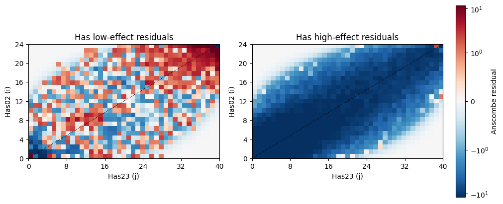

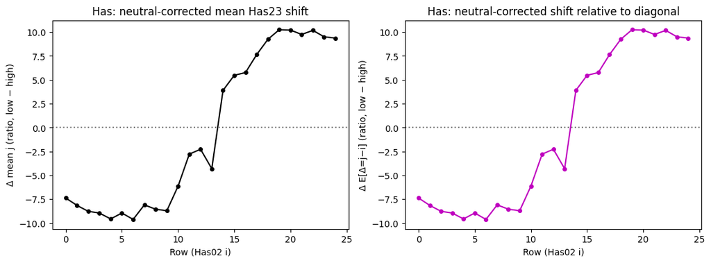

```python
has_params, has_model, has_resid_df = compare_residual_shifts("Has", Has_low, Has_high)
```

## Subsampling Low-Effect Mutations for Comparison

To assess whether high-effect mutations differ significantly from low-effect ones, we:

1. **Subsampled** the low-effect mutations to match the number of high-effect mutations.
2. **Calculated** the mean effect size for each subsample.
3. **Compared** the observed mean of high-effect mutations to the distribution of subsampled low-effect means.

This approach evaluates whether the mean effect of high-impact variants exceeds what would be expected by chance from low-effect variants.

**Utility Function: Normalise Row to Probabilities** Convert a row of allele counts into probabilities — ensures each row sums to 1.

**Show codeHide codeCopyable source**

```python
def normalize_row(c):
    c = np.asarray(c, float)
    s = c.sum()
    return c / s if s > 0 else np.zeros_like(c)
```

**Generate Null Distribution via Subsampling** Subsample low-effect mutations to match the count of high-effect ones and compute mean distributions.

**Show codeHide codeCopyable source**

```python
def subsample_low_effect_means(sfs_low, sfs_high, row_index, n_reps=2000, rng=None):
    """
    For a given row (i = derived allele count in pop1),
    - Expand low-effect mutation spectrum into a list of allele counts.
    - Subsample the same number as high-effect alleles.
    - Compute the mean allele count in pop2 for each replicate.
    Returns:
      rep_means = distribution of means (null)
      mean_of_means = mean of null distribution
    """
    if rng is None:
        rng = np.random.default_rng(42)

    cH = sfs_high.data[row_index].astype(int)
    cL = sfs_low.data[row_index].astype(int)
    nH, nL = cH.sum(), cL.sum()

    if nH == 0 or nL == 0 or nL < nH:
        return None, None

    alleles = []
    for j_value, freq in enumerate(cL):
        alleles.extend([j_value] * freq)

    rep_means = np.array([
        rng.choice(alleles, size=nH, replace=False).mean()
        for _ in range(n_reps)
    ])
    return rep_means, rep_means.mean()
```

**Empirical P-Value Calculation** Estimate how extreme the observed mean is relative to the null distribution.

**Show codeHide codeCopyable source**

```python
def calculate_empirical_p_value(observed_stat, null_dist):
    """
    Compute two-sided empirical p-value centered around null mean.
    +1 pseudocount avoids zero p-values.
    """
    n = len(null_dist)
    mu0 = np.mean(null_dist)
    extreme = np.sum(np.abs(null_dist - mu0) >= np.abs(observed_stat - mu0))
    return (extreme + 1) / (n + 1)
```

**Plot Mean Comparison** Visualize observed high-effect means against null distributions from low-effect subsampling.

**Show codeHide codeCopyable source**

```python
def plot_mean_comparison(sfs_high, sfs_low,
                         n_reps=2000,
                         pop1_name="Has02", pop2_name="Has23",
                         bins=30):
    """
    Create grid panels (one per SFS row) showing:
      - Blue: null distribution from low-effect subsamples
      - Red: observed high-effect mean
      - Dashed blue: null mean
      - Title: permutation p-value
    """
    n_rows = sfs_high.data.shape[0]
    rows = np.arange(1, n_rows)

    rng = np.random.default_rng(42)
    fig, axes = plt.subplots(6, 4, figsize=(20, 15))
    axes = axes.flatten()

    fig.suptitle(
        f"Permutation Test: High vs. Low Effect Mutations ({pop1_name} → {pop2_name})",
        fontsize=20
    )

    for idx, i in enumerate(rows):
        ax = axes[idx]
        rep_means, mean_of_means = subsample_low_effect_means(
            sfs_low, sfs_high, i, n_reps=n_reps, rng=rng
        )
        if rep_means is None:
            ax.text(0.5, 0.5, f"Row {i}\n(no data)", ha="center", va="center", transform=ax.transAxes)
            ax.set_axis_off()
            continue

        cH = sfs_high.data[i].astype(float)
        pH = normalize_row(cH)
        j_vals = np.arange(len(pH))
        mean_high = float(np.dot(j_vals, pH))

        p_perm = calculate_empirical_p_value(mean_high, rep_means)

        ax.hist(rep_means, bins=bins, density=True, color="blue", alpha=0.6, edgecolor="black")
        ax.axvline(mean_high, color="red", linestyle="--", lw=2, label="High-effect mean")
        ax.axvline(mean_of_means, color="darkblue", linestyle=":", lw=2, label="Low-effect mean")

        ax.set_title(f"Row {i} | Perm. p={p_perm:.3f}", fontsize=10)
        ax.set_xlabel(f"Mean derived allele count in {pop2_name}")
        ax.set_ylabel("Density")

        if idx == 0:
            ax.legend(fontsize=8, loc="upper left", frameon=True)

    for j in range(len(rows), len(axes)):
        fig.delaxes(axes[j])

    plt.tight_layout(rect=[0, 0, 1, 0.95])
    plt.show()
```

**Example Usage** Run the comparison for two timepoints (Has02 → Has23) of the population .

**Show codeHide codeCopyable source**

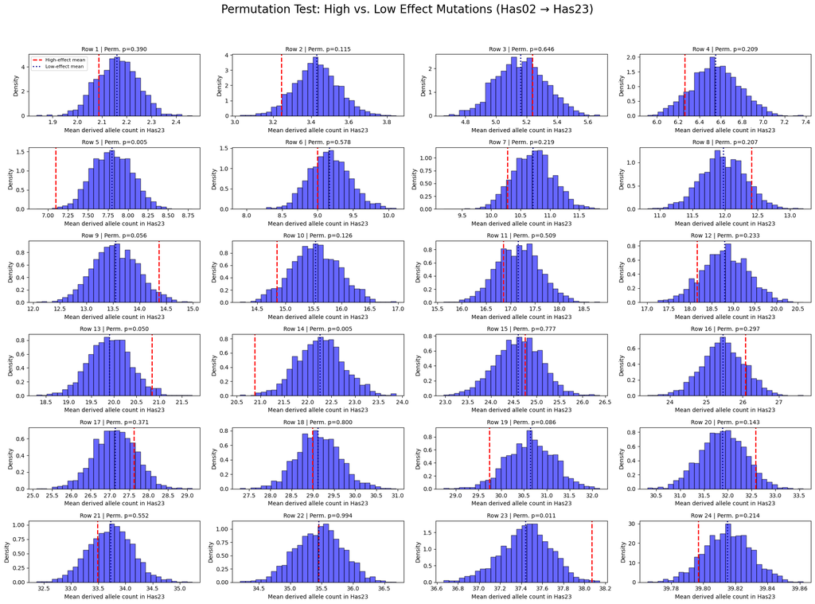

```python
plot_mean_comparison(Has_high, Has_low, n_reps=2000, pop1_name="Has02", pop2_name="Has23")
```

### 10.1. Comparison: High vs. Low Effect Mutations

**Normalize a Row of Counts** Convert a row of allele counts into probabilities that sum to 1.

**Show codeHide codeCopyable source**

```python
# ----------------------------
# Normalize a count vector into probabilities
# ----------------------------
# === Take a row of SFS counts and turns it into a probability distribution ===
def normalize_row(c):
    c = np.asarray(c, float)
    s = c.sum()
    return c / s if s > 0 else np.zeros_like(c)

# === Build a null distribution of mean allele counts by repeatedly subsampling low-effect alleles to match the size of the high-effect sample ===
def subsample_low_effect_means(sfs_low, sfs_high, row_index, n_reps=2000, rng=None):
    # Set random number generator
    if rng is None:
        rng = np.random.default_rng(42)

    # Extract row counts for high- and low-effect mutations
    cH = sfs_high.data[row_index].astype(int)
    cL = sfs_low.data[row_index].astype(int)

    # Total counts in that row
    nH, nL = cH.sum(), cL.sum()

    # Skip if too few counts
    if nH == 0 or nL == 0 or nL < nH:
        return None, None

    # Expand low-effect SFS row into individual allele counts
    alleles = []
    for count_val, freq in enumerate(cL):
        if freq > 0:
            alleles.extend([count_val] * int(freq))

    # Subsample repeatedly to match high-effect sample size
    rep_means = np.empty(n_reps, dtype=float)
    for r in range(n_reps):
        samp = rng.choice(alleles, size=nH, replace=False)
        rep_means[r] = samp.mean()

    return rep_means, float(rep_means.mean())

# === Compute two-sided permutation p-value for whether the high-effect mean is unusual compared to the null ===
def empirical_p_value_mean(observed_mean, null_means):
    # Compare observed mean to distribution of null means
    center = np.mean(null_means)
    obs_dev = abs(observed_mean - center)
    null_devs = np.abs(null_means - center)
    n = len(null_means)
    extreme = np.sum(null_devs >= obs_dev)
    return (extreme + 1) / (n + 1)  # add +1 pseudocount

# === Return two metrics: JSD (continuous measure of divergence between SFS shapes). Chi² p-value (significance of shape differences) ===

def jsd_and_chi2_from_sfs(cH, cL):
    # Ignore positions where both are zero
    mask = (cH + cL) > 0
    cH_ = cH[mask].astype(float)
    cL_ = cL[mask].astype(float)

    # Normalize to probability distributions
    pH = normalize_row(cH_)
    pL = normalize_row(cL_)

    # Jensen-Shannon divergence (distribution similarity)
    try:
        jsd = float(jensenshannon(pH, pL, base=2.0))
    except Exception:
        jsd = np.nan

    # Chi-square test (compare raw counts)
    try:
        table = np.vstack([cH_, cL_])
        chi2, p_chi, dof, expected = chi2_contingency(table, correction=False)
        p_chi = float(p_chi)
    except Exception:
        p_chi = np.nan

    return jsd, p_chi

# === Prepare figure with multiple subplots (each row of SFS = one subplot) ===
def plot_comprehensive_comparison(sfs_high, sfs_low,
                                  n_reps=2000,
                                  pop1_name="Has02", pop2_name="Has23",
                                  bins_low=10):
    # Number of rows in SFS (pop1 allele counts)
    n_rows = sfs_high.data.shape[0]
    rows = np.arange(1, n_rows)   # skip trivial row 0
    rng = np.random.default_rng(42)

    # Create subplot grid
    fig, axes = plt.subplots(6, 4, figsize=(24, 18))
    fig.suptitle(
        f"Row-wise SFS Shape and Mean Comparison: High vs Low-effect ({pop1_name} → {pop2_name})",
        fontsize=22, y=0.995
    )
    axes = axes.flatten()

# === For each row, build the null distribution of low-effect means --- #
    for idx, i in enumerate(rows):
        ax = axes[idx]

        # Get null distribution of subsampled low-effect means
        rep_means, mean_of_means = subsample_low_effect_means(
            sfs_low, sfs_high, i, n_reps=n_reps, rng=rng
        )
        if rep_means is None:
            ax.text(0.5, 0.5, f"Row {i}\n(no data)", ha='center', va='center',
                    transform=ax.transAxes)
            ax.set_axis_off()
            continue

# === Prepare the two distributions, calculates means, JSD, Chi², and permutation p-value ===
        # Extract SFS counts
        cH = sfs_high.data[i].astype(float)
        cL = sfs_low.data[i].astype(float)

        # Normalize to probability distributions
        pH = normalize_row(cH)
        pL = normalize_row(cL)
        x = np.arange(len(pH))

        # Mean of high-effect SFS
        mean_high = float(np.dot(x, pH))

        # Compute statistics
        jsd, p_chi = jsd_and_chi2_from_sfs(cH, cL)
        p_perm = empirical_p_value_mean(mean_high, rep_means)

# === Plot red = high-effect SFS, blue = low-effect SFS; histogram = subsampled low-effect means ===
        # Plot SFS distributions
        ax.plot(x, pH, color='red', lw=2, label='High-effect SFS')
        ax.plot(x, pL, color='blue', lw=2, linestyle=':', label='Low-effect SFS')
        ax.axvline(mean_high, color='red', linestyle='--', lw=2, label='High-effect mean')

        # Second y-axis for histogram of subsampled low-effect means
        ax2 = ax.twinx()
        ax2.hist(rep_means, bins=bins_low, density=True, color='blue',
                 alpha=0.15, edgecolor='black', linewidth=0.5,
                 label=f'Subsampled means ({n_reps} reps)')
        ax2.axvline(mean_of_means, color='blue', linestyle='--', lw=2,
                    label='Mean of subsampled means')

# === Subplot title show all test results for that row ===
        # Annotate with results
        ax.set_title(
            f"Row {i} | JSD={jsd:.3f}, χ² p={p_chi:.2e} (compare SFS shape)\n"
            f"Permutation p={p_perm:.3f} (compare means)",
            fontsize=12
        )

# === Clean up figure and display ===
    for j in range(len(rows), len(axes)):
        fig.delaxes(axes[j])  # remove unused subplots
    plt.tight_layout(rect=[0, 0.02, 1, 0.96])
    plt.show()
```

### 10.2. Example usage

**Show codeHide codeCopyable source**

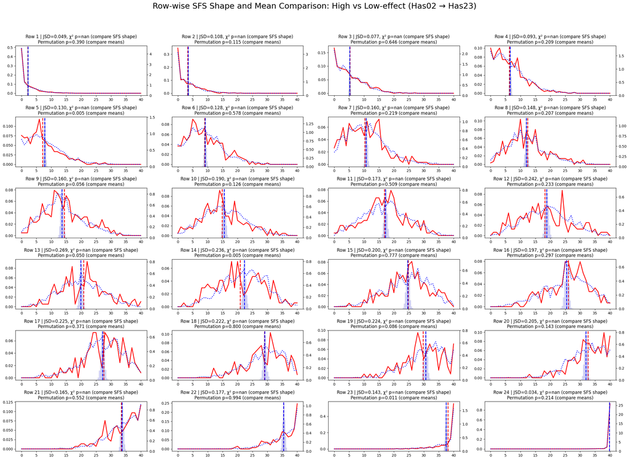

```python
plot_comprehensive_comparison(Has_high, Has_low, n_reps=2000,
                               pop1_name="Has02", pop2_name="Has23")
```

## 11 Discussion, interpretation & exercises

**Questions to think about**

- Which effect classes show an excess of rare derived alleles in the recent timepoint (Has23)?
- Where do model residuals show strong deviations from the neutral expectation?
- How would selection vs migration shape the residual patterns?

**Exercises**

1. Change `projections` to smaller/larger values and observe smoothing of the 2dSFS.
2. Increase bootstrap `B` and inspect CI stability.
3. Modify the neutral model (allow asymmetric migration) and compare fits.
4. Repeat the pipeline for another population or time series.